# 強化学習モデル入門

シミュレーションとパラメータ推定

国里愛彦

# 計算論的精神医学

## 計算論的アプローチとは？

- 私達や動物の行動の背後にある計算過程を数式で表現したモデルを用いること。
- ここでの計算は意識的な計算に限定されず、脳内のあらゆる情報処理においてなされる無意識的な計算も含む。

## Marrの３つの階層

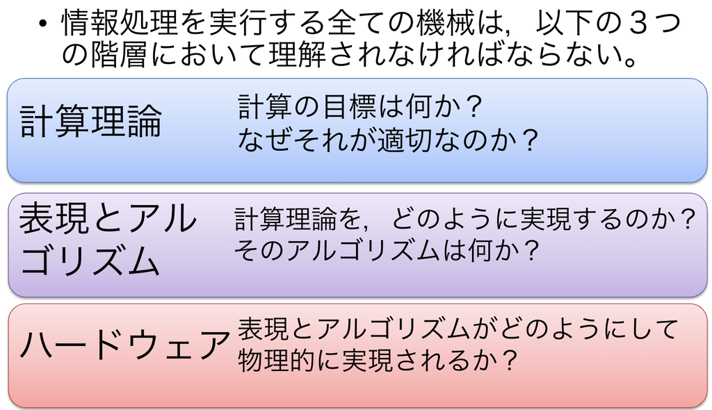

## 計算論的神経科学

- 入力から出力をつなぐ脳内の情報処理過程を数理モデルとして表現し検討

→解くべき問題に対して，情報処理機械が作れるくらいにアルゴリズムと生物学的基盤を調べる

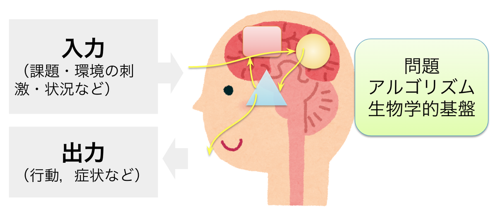

## 計算論的精神医学

- 2010年代より計算論的神経科学の応用領域としてスタート
- 総説論文：Huys, Moutoussis, and Williams (2011) , Maia and Frank (2011), Montague et al. (2012)
- テキスト：『Computational Psychiatry』(Anticevic and Murray 2017)，『計算論的精神医学』(国里愛彦・片平健太郎・沖村宰・山下祐一 2019)

[figure not shown]

## 計算論的精神医学研究と生成モデル

- 計算論的精神医学の目標は，精神疾患の生成モデルを作ること
- 生成モデルは，患者の呈するデータ（症状や行動など）が生成される過程をモデル化したもの

→優れた生成モデルは，精神疾患の理解につながると同時に，有効な疾患マーカーにもなるかも

## データ，生成モデル，パラメータ

- 入力からデータを生成するプロセスを記述するモデルが生成モデルであり，その調節つまみがパラメータ
- 生成モデルは研究者が設定したもの

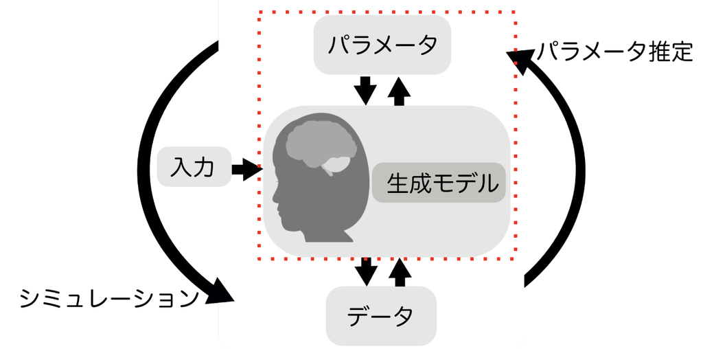

## データ，生成モデル，パラメータ

- パラメータと生成モデルを設定し，入力を入れると，シミュレーション（人工データの生成）ができる

→精神疾患のシミュレーション

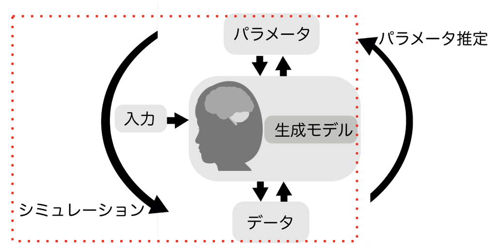

## データ，生成モデル，パラメータ

- 生成モデルを設定すれば，データと入力からパラメータを推定することもできる

→データから精神疾患患者のパラメータを推定

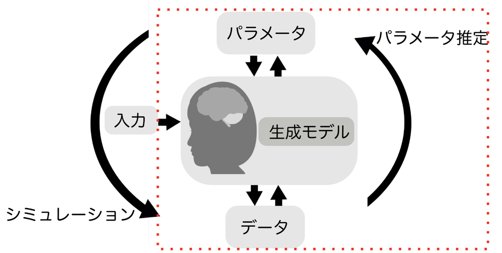

## 計算論的精神医学への期待

- 疾患マーカーの洗練化（行動・脳画像データに数理モデルを適用して疾患のメカニズムを推測する計算論的検査（computational assay, Stephan and Mathys (2014)))
- 症状・行動水準と生物学的水準との間の説明のギャップを数理モデルが埋める
- 数理モデルを用いた理論の統合
- 効果的な治療法の探索（疾患メカニズムのモデルができれば，シミュレーションによる探索が可能？）

## 4つの生成モデル

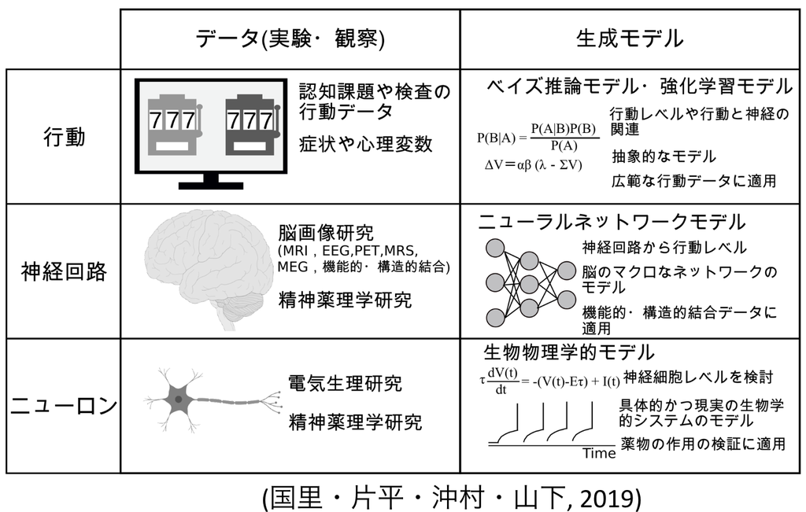

# 強化学習モデル

## Rescorla-Wagnerモデル

- 古典的条件づけにおけるCS（条件刺激）とUS（無条件刺激）の連合強度の変化プロセスをモデル化したもの
- CS-USの連合強度$V$は、以下の更新式を用いて、試行ごとに更新される($\alpha$は学習率、$r$は報酬つまりUS)。

$$V_{t+1} = V_{t}+\alpha(r_{t}-V_{t})$$

※RWモデルではCSの明瞭度の$\alpha$とUSの強度の$\beta$を掛け合わせたものを学習率に使うが、上では$\alpha$に統合している

## Rescorla-Wagnerモデル

- RWモデルは連合強度に限らず、何かの刺激の価値の更新過程に用いられる最も基本的なモデルになる。
- $r_{t}-V_{t}$は期待と実際の報酬とのズレを表す報酬予測誤差になり、この報酬予測誤差をどのくらい反映して価値の更新をするのか調整するのが学習率$\alpha$

$$V_{t+1} = V_{t}+\alpha(r_{t}-V_{t})$$

## TD誤差学習

- RWの予測誤差の考えを時間方向に展開すると強化学習モデルのTD(Temporal Difference)誤差学習につながる。
- まだ学習が成立していない条件づけの獲得フェーズでは、USの提示の時にVが上がる。

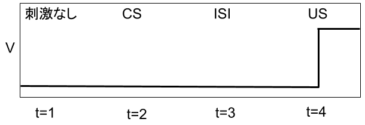

## TD誤差学習

- 学習が成立後は、CSが提示された段階でVが上がり、US提示時まで維持される。

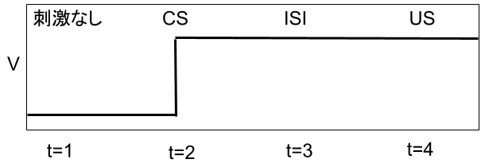

## ドーパミンとTD誤差

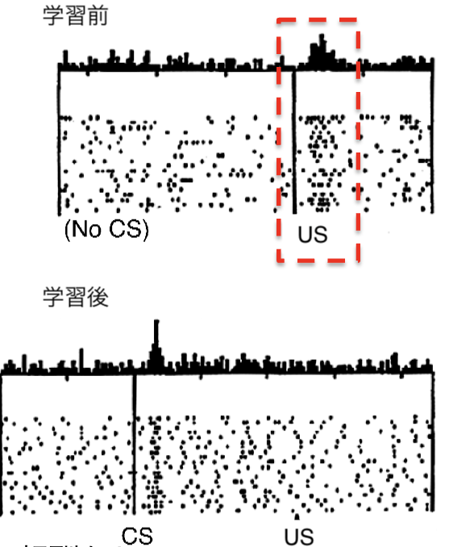

- Schultz, Dayan, and Montague (1997) の実験
- 予期しないタイミングでUSがくる→ドーパミン活動増
- CSで予期できた状態でUSがくる→ドーパミン活動変化なし

## ドーパミンとTD誤差

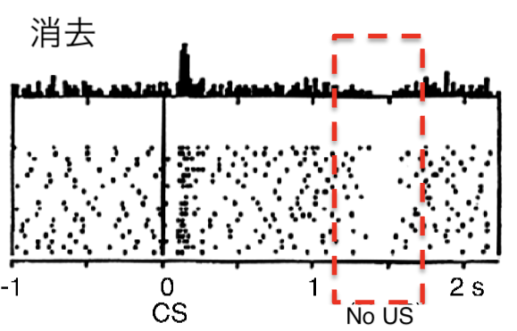

- CSで予期できたのにUSがこない→ドーパミン活動減
- ドーパミンはTD誤差に反応

## 強化学習モデル

- 「長期的にみて報酬を最大化するために，環境の状態に対して，特定の行動を学習するエージェントについての計算論的な枠組み」
- 学習心理学で得られた知見などをベースに機械学習分野で発展してきたモデル（現在の生成AIでも活用されている）
- [Sutton＆Bartoの教科書](https://www.morikita.co.jp/books/mid/082662)が有名

## 強化学習モデルの特徴

- 将来の報酬と罰を予測することの学習（古典的条件づけ）と将来の報酬を最大化する行動を選択することの学習（道具的条件づけ）をモデル化(Anticevic and Murray 2017)。
- 脳のモデルとしても使われるが，主に行動データの説明に活用されることが多い。
- 学習の速度を調節する学習率などのパラメータがあり，それらのパラメータと精神疾患との関連を検討できる。

## Q learning Model

- Ｑlearning Model(Watkins, Machine Learning,1989)：TD誤差(δ)をできるだけ小さくするように，Q値の更新していくことで，最適な行動価値関数を学習するモデル。

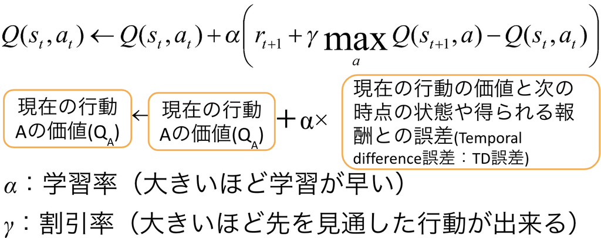

## 逆転学習課題

- スロットマシーンが２つあり，どちらかのスロットの方が報酬が出る(例.紫を選択すると70%の確率で報酬がでて，緑を選択すると30%の確率で報酬がでる）
- しばらくすると，報酬の出る確率が逆転する（例.紫が30%，緑が70%）

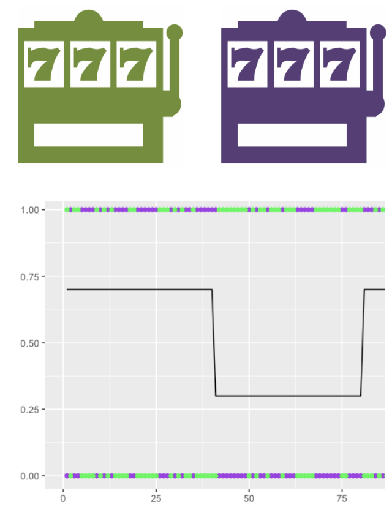

## 学習率と価値の更新

- Q learning Modelでは，ある選択肢を選ぶ価値は，TD誤差に学習率(α)を掛けたものによって更新される。
- 期待と報酬にズレがあると学習が進む！
- 学習率(α)が大きいと学習が早く進む！

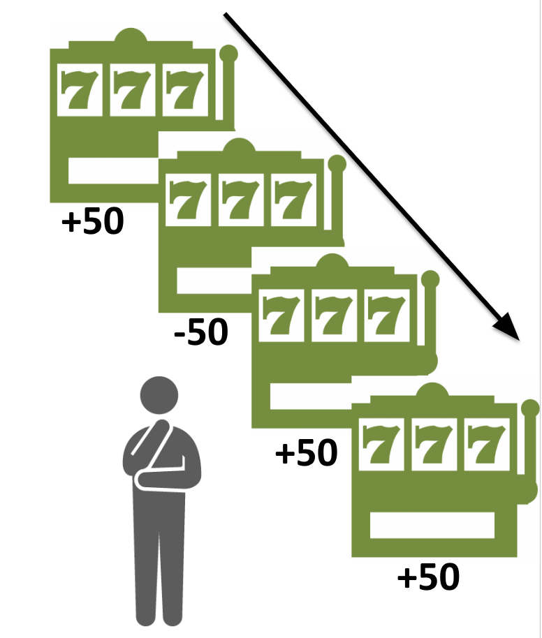

## αのシミュレーション

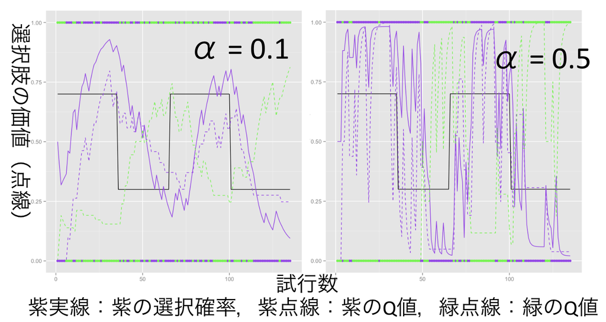

- 学習率(α)が大きいと敏感にFBに反応して，Q値を更新

## 方策：探索と利用

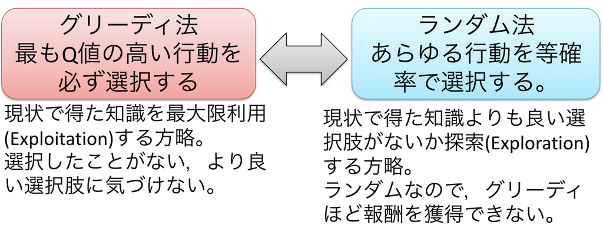

- 探索（ランダム法）と利用（グリーディ法）のバランスをとることが重要

## ソフトマックス行動選択

- Q値で確率分布（ボルツマン分布）を作ることで方策とする方法
- 逆温度(inverse temperature: β)で探索と利用のバランスをとる(βは0以上の値，β=0でランダム法，βが大きくなるとグリーディ法)

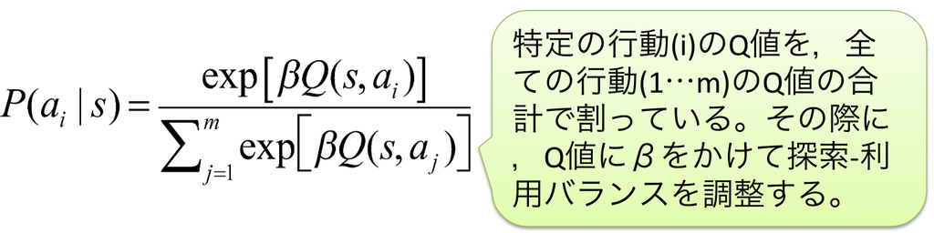

## 逆転学習課題の場合

- 緑と紫スロットの選択の場合

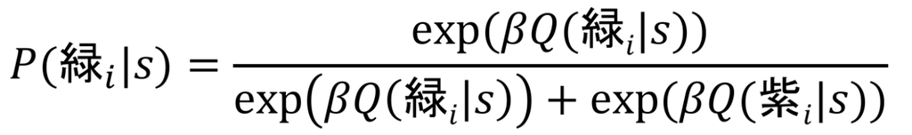

- βは0に近づくほど，選択確率は0.5に近づく（価値の差が選択に反映されなくなる）

## βのシミュレーション

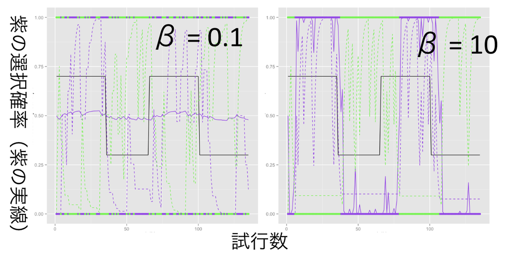

- βが小さいと選択確率は0.5に近づく（ランダム法）
- βが大きいとQ値を敏感に反映した選択確率になる（グリーディ法）。

## 強化学習モデルの利点

- 環境との相互作用が必要な意思決定を少ないパラメータ数でモデル化できる。
- 実際に得られた行動データからパラメータ推定ができるので，精神疾患患者の行動データから疾患に関連する強化学習モデルのパラメータを特定できる。

→行動が生成されるに至った内的なプロセスにおける差異についても検討できる。

## 強化学習モデルの改変

- 強化学習モデルは学習率と逆温度が１つとは限らない
- 学習率：予測誤差が正か負で分ける、課題のフェーズに合わせて分ける、課題中に変動させるなど
- 逆温度：学習が進むとグリーディになるとして逆温度が徐々に上がるように設定など
- 他のパラメータ：前と同じ反応を選択する固執性パラメータを追加することもできる

→変動性に関心があれば強化学習モデルの延長線でベイズ推論モデルへ

## モデルフィッティング

- 実際ある行動データなどから，生成モデルを用いてパラメータ推定を行い，そのパラメータの値を検討する方法（推定法は最尤法やベイズ推定）。モデルベース解析、モデルフィッティング、パラメータ推定など

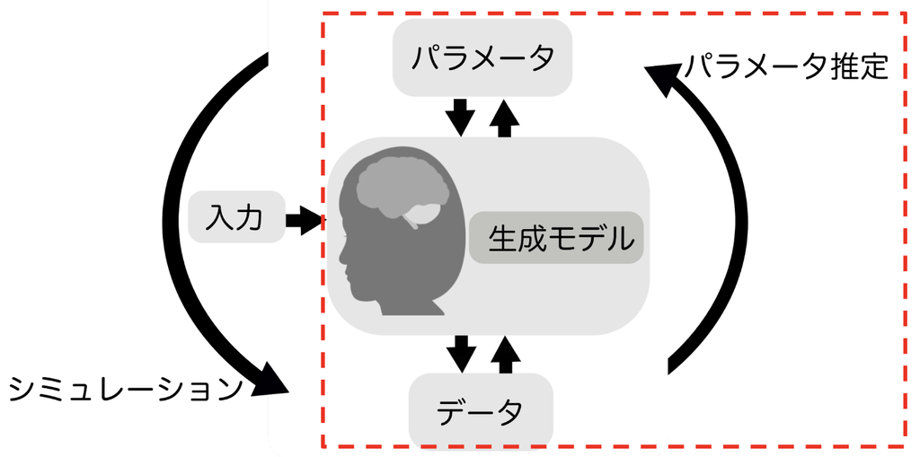

## パラメータ推定

①パラメータを含む生成モデルを設定

→強化学習モデル，ベイズ推論モデル

②パラメータを評価する基準を設定

→対数尤度（各時点の選択に対する選択確率を総積したものの対数をとったもの）

③最良の評価を与えるパラメータを決定する

→最尤法

→MCMC法や変分ベイズ法

## モデル選択

- モデルフィッティングは，複数の生成モデルを用意してモデル選択をするのが望ましい

→選択にあたり，データへの適合度を，情報量規準(AIC,BIC,BFなど)などで評価する

- 情報量規準による評価は相対モデル比較であり，モデルが関心のある効果を再現できることを示す生成パフォーマンスは示せない(Palminteri et al., 2017)。

→モデル・シミュレーション(推定されたパラメータを用いたシミュレーション)で検証

## モデルフィッティング

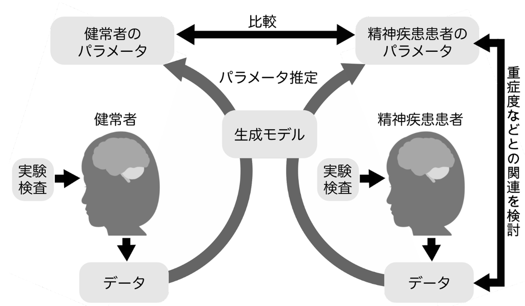

- パラメータを患者と健常者で比較（精神疾患の行動的特徴の生成過程の検討）
- パラメータと患者の症状重症度や心理・認知的変数との相関を検討（症状の増悪・緩和にかかわる要因の検討）

# Rで強化学習入門

### 「R/Pythonではじめる計算論的精神医学」

- 宗田卓史 et al. (2025) によるRとPythonを用いた計算論的精神医学の入門用教科書
- 以降では、本書のコードを少し改変して使用

[figure not shown]

## 逆転学習課題を試そう！

- [逆転学習課題のデモ](https://cba-toolbox.github.io/probabilistic-reversal-learning-task/demo_probabilistic-reversal-learning.html) : jsPsychで作成した逆転学習課題のデモ。最後まで取り組むとcsvファイルがダウンロードされるので、パラメータ推定に使える（データはご自身のローカルPCのみに保存される）。
- [逆転学習課題のCBATリポジトリ](https://github.com/cba-toolbox/probabilistic-reversal-learning-task)

## Rパッケージ

- 用いるRパッケージは、tidyverseパッケージだけ
- RStudioでQmdファイルを開くかRファイルを開いて、以降のコードを貼り付けて実行ください（もしtidyverseパッケージが入ってない場合は、インストールください）。

```r
library(tidyverse)
```

## 関数を作る

- Rではある程度まとまった処理を複数回実施する場合は関数化すると便利
- 関数を作る場合は、”関数名 <- function(引数){}”で指定します。引数を指定すると関数で指定した処理をして出力する。

```r
func_A <- function(a,b){
  a + b
}

func_A(1,4)
```

```
[1] 5
```

## 数字の列を作る

- 同じ数字を繰り返すrep(繰り返す数字、繰り返し回数)関数
- 連番を作成するseq(最初の数字、最後の数字、by=間隔)関数

```r
# 同じ数値を繰り返す
rep(1,5)
```

```
[1] 1 1 1 1 1
```

```r
# 連続した数値の生成(1から10まで1の間隔で）
seq(1,10,by=1)
```

```
 [1]  1  2  3  4  5  6  7  8  9 10
```

## サンプリングする

- sample()関数を使うと、要素の集合からランダムに指定した数の要素を抽出できる

```r
sample(c(1,2,3,4,5,6,7,8,9),1)
```

```
[1] 5
```

## runifによるサンプリング

- 0から1の範囲で一様乱数を発生させるrunif()関数（指定した確率で実現値を作る場合に便利）。

```r
runif(1)
```

```
[1] 0.1074802
```

- 0.8 > runif(1)つまり一様乱数が0.8よりも小さい確率は80%なので、Aを80%、Bを20%で表示できる。

```r
if(0.8 > runif(1)){
  print("A")
} else {
  print("B")
}
```

```
[1] "A"
```

## データフレームの作成

- numeric()を使うと指定した数だけ要素ゼロのベクトルを作れる。

```r
numeric(5)
```

```
[1] 0 0 0 0 0
```

- Rでは分析用のデータセットは、データフレーム型にする。tibble()を使うと便利。

```r
data <- tibble(
  a = c(1,2,3),
  b = seq(1,3),
  c = rep("C",3)
)
data
```

```
# A tibble: 3 × 3
      a     b c
  <dbl> <int> <chr>
1     1     1 C
2     2     2 C
3     3     3 C
```

```r
# $を使うことで変数を取り出せる
data$a
```

```
[1] 1 2 3
```

## 逆転学習課題の設定

- 逆転学習課題の設定情報を用意するfunc_TaskSetting関数を作る（前半80試行はAが80%の確率で正答、後半80試行はBが80%の確率で正答）

```r
func_TaskSetting <- function(pA = 0.8){ #pAのデフォルトは0.8に設定
  # outA: 逆転前はpAの確率で報酬(1)，1-pAの確率で報酬なし(0)。逆転後は逆
  # outB: 逆転前は1-pAの確率で報酬(1)，pAの確率で報酬なし(0)。逆転後は逆
  tibble(
    block = c(rep(1,80),rep(2,80)),# 各ブロック80試行
    trial = seq(1,160),
    outA = c(sample(c(1,0), 80, prob= c(pA, 1-pA), replace = TRUE),
             sample(c(1,0), 80, prob= c(1-pA, pA), replace = TRUE)),
    outB = c(sample(c(1,0), 80, prob= c(1-pA, pA), replace = TRUE),
             sample(c(1,0), 80, prob= c(pA, 1-pA), replace = TRUE))
    )
}
```

## 逆転学習課題の設定用関数の確認

- func_TaskSettingで設定情報を出力して確認(0,1データなので平均すると正答確率になる)

```r
setting <- func_TaskSetting(0.8)

setting |>
  group_by(block) |> # blockごとに集計
  summarise(A = mean(outA),
            B = mean(outB))
```

```
# A tibble: 2 × 3
  block     A     B
  <dbl> <dbl> <dbl>
1     1   0.8 0.162
2     2   0.2 0.788
```

## 可視化

- ggplotでプロットして確認（outAだけプロットしてるが、outBはAの逆になる）

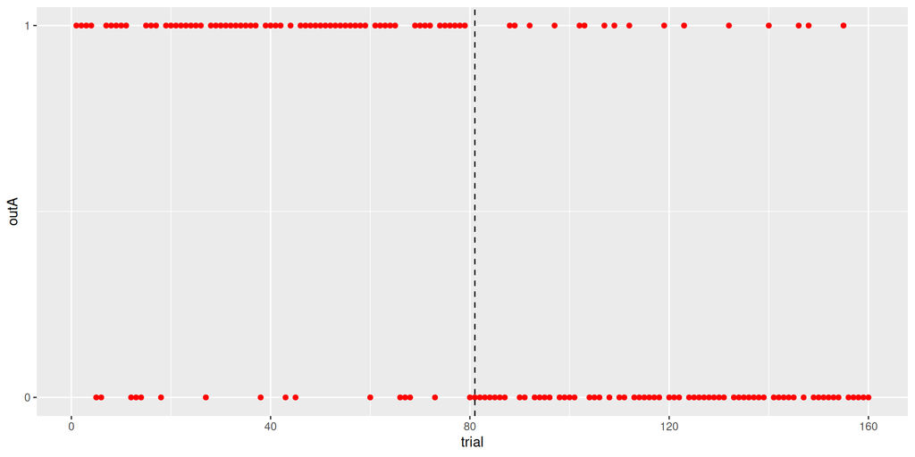

```r
ggplot(setting, aes(x = trial, y = outA))+ #データフレーム，x軸，y軸を設定
  geom_point(color = "red")+ # geom_point()で散布図を作成
  geom_vline(xintercept = 81, lty = "dashed")+ # 81試行目に垂線を引く
  scale_y_continuous(breaks=c(0,1))+ # y軸の目盛り設定
  scale_x_continuous(breaks=seq(0, 160, by=40)) # x軸の目盛り設定
```

## 強化学習モデル

- 行動価値Qの更新式（Rは報酬、αは学習率）

$$Q = Q + \alpha (R - Q)$$

```r
alpha <- 0.2
Q <- 0.4 # 更新前Q値
R <- 1 # 1: 報酬あり, 0: 報酬なし
Q <- Q + alpha*(R - Q)
Q # 更新後のQ値
```

```
[1] 0.52
```

## 学習率を動かして理解する

- αをいろいろな値に変えてQ値の更新値を確認

```r
alphas <- seq(0,1,0.2) # 0から1まで0.2刻みの連番
for (i in alphas){
  alpha <- i
  Q <- 0.4 #更新前のQ値
  R <- 1
  Q <- Q + alpha*(R - Q)
  Q # 更新後のQ値
  cat("alpha:", i, ",更新後のQ値:", Q, end = "\n")
}
```

```
alpha: 0 ,更新後のQ値: 0.4
alpha: 0.2 ,更新後のQ値: 0.52
alpha: 0.4 ,更新後のQ値: 0.64
alpha: 0.6 ,更新後のQ値: 0.76
alpha: 0.8 ,更新後のQ値: 0.88
alpha: 1 ,更新後のQ値: 1
```

## 行動選択ルール

- 2選択肢（AとB）の選択確率はソフトマックス行動選択を用いる
  $$P(A) = \frac{e^{\beta Q_{A}}}{e^{\beta Q_{A}} + e^{\beta Q_{B}}}$$
- 以下の式でも同じであり、プログラムを書く上でこっちの方が書きやすい
  $$P(A) = \frac{1}{1+e^{\beta (Q_{B}-Q_{A})}}$$

## 行動選択ルール

$$P(A) = \frac{1}{1+e^{\beta (Q_{B}-Q_{A})}}$$

```r
beta <- 5 # βの値
Q_A <- 1.0 # Aの価値
Q_B <- 0.8 # Bの価値
P_A <- 1/(1+exp(-beta*(Q_A -Q_B)))
P_B <- 1-P_A
cat("Aの選択確率: ", P_A, end="\n")
```

```
Aの選択確率:  0.7310586
```

```r
cat("Bの選択確率: ", P_B)
```

```
Bの選択確率:  0.2689414
```

## 逆温度を動かして理解する

- 逆温度をいろいろな値に変えてAの選択確率を確認

```r
# 0から5まで範囲で逆温度を用意
betas <- c(0.0, 0.5, 1.0, 2.0, 5.0, 10.0)
for (i in betas){
  betas <- i
  Q_A <- 1.0 # Aの価値
  Q_B <- 0.8 # Bの価値
  P_A <- 1/(1+exp(-betas*(Q_A -Q_B)))
  cat("beta:", i, ",Aの選択確率:", P_A, end = "\n")
}
```

```
beta: 0 ,Aの選択確率: 0.5
beta: 0.5 ,Aの選択確率: 0.5249792
beta: 1 ,Aの選択確率: 0.549834
beta: 2 ,Aの選択確率: 0.5986877
beta: 5 ,Aの選択確率: 0.7310586
beta: 10 ,Aの選択確率: 0.8807971
```

## 行動データの生成

- シミュレーション（行動データ生成）用関数func_DataGenerationの作成

```r
func_DataGeneration <- function(param, setting){
  # 引数のparmに基づいてパラメータを設定
  alpha <- param[1] # 学習率はparamの一つ目の値
  beta <- param[2] # 逆温度はparamの二つ目の値
  # 引数のsettingに基づいて課題の設定
  outA <- setting$outA # 各試行でAを選んだ場合の結果
  outB <- setting$outB # 各試行でBを選んだ場合の結果
  trials <- setting$trial # 試行番号（1~160）
  Ntrial <- length(trials) # 試行数
  # 各試行の情報を入れていく変数の設定（試行数分の整数型ベクトル）
  c <- numeric(Ntrial) # 各試行の選択を入れる変数
  r <- numeric(Ntrial) # 各試行の報酬結果を入れる変数
  Q_A <- numeric(Ntrial) # 各試行のAのQ値を入れる変数
  Q_B <- numeric(Ntrial) # 各試行のBのQ値を入れる変数
  p_A <- numeric(Ntrial) # 各試行のAの選択確率を入れる変数
  RPE <- numeric(Ntrial) # 各試行の報酬予測誤差を入れる変数
  # Qの初期値の設定
  Q_A[1] <- 0.5
  Q_B[1] <- 0.5
  # 選択と価値の更新
  for (t in 1:Ntrial){# for文で試行数分繰り返す。
    # 選択肢Aの選択確率
    p_A[t] <- exp(beta*(Q_A[t]))/(exp(beta*(Q_A[t])) + exp(beta*(Q_B[t])))
    # 選択確率に基づく0~1の乱数を１つ発生させ，それを受け選択を生成
    if(p_A[t] > runif(1)){ # 乱数の値がp_A（Aの選択確率）より小さいとき
      c[t] <- 1 # choice A
      r[t] <- outA[t]
      RPE[t] <- r[t]-Q_A[t]
    } else { # 乱数がp_A以上のとき
      c[t] <- 2 # choice B
      r[t] <- outB[t]
      RPE[t] <- r[t]-Q_B[t]
    }
    # 価値の更新
    if(t < Ntrial){
      if(c[t] == 1){ # Aを選択していた場合
        Q_A[t+1] <- Q_A[t] + alpha*RPE[t]
        Q_B[t+1] <- Q_B[t]
      }
      if(c[t] == 2){ # Bを選択していた場合
         Q_B[t+1] <- Q_B[t] + alpha*RPE[t]
         Q_A[t+1] <- Q_A[t]
      }
    }
  }
  # 結果のまとめ（戻り値）
  tibble(
    trial = trials,
    QA = Q_A,
    QB =Q_B,
    choice = c,
    reward = r,
    pA = p_A,
    pB = 1-p_A,
    RPE = RPE)
}
```

## １名分のデータ生成

- func_DataGeneration関数でデータ生成してみる（学習率0.2,逆温度5.0）。

```r
# 乱数のシードを固定
set.seed(123)
tmp_param <- c(0.2, 5)
tmp_setting <- func_TaskSetting(0.8)
data <- func_DataGeneration(tmp_param, tmp_setting)
print(data)
```

```
# A tibble: 160 × 8
   trial    QA    QB choice reward    pA    pB    RPE
   <int> <dbl> <dbl>  <dbl>  <dbl> <dbl> <dbl>  <dbl>
 1     1 0.5    0.5       2      0 0.5   0.5   -0.5
 2     2 0.5    0.4       1      1 0.622 0.378  0.5
 3     3 0.6    0.4       1      1 0.731 0.269  0.4
 4     4 0.68   0.4       1      0 0.802 0.198 -0.68
 5     5 0.544  0.4       1      0 0.673 0.327 -0.544
 6     6 0.435  0.4       1      1 0.544 0.456  0.565
 7     7 0.548  0.4       2      0 0.677 0.323 -0.4
 8     8 0.548  0.32      1      0 0.758 0.242 -0.548
 9     9 0.439  0.32      1      1 0.644 0.356  0.561
10    10 0.551  0.32      2      0 0.760 0.240 -0.32
# ℹ 150 more rows
```

## １名分のデータの確認

- 生成したデータをggplotでプロットして確認

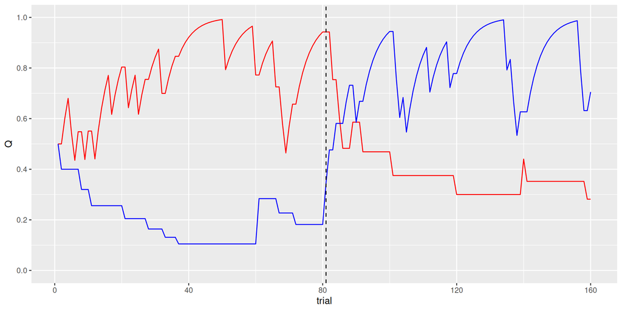

```r
ggplot(data, aes(x = trial, y = QA))+
  geom_line(color = "red")+ # QAを赤でプロット
  geom_line(aes(y = QB),color = "blue")+ # yの指定だけQBに変更し青でプロット
  geom_vline(xintercept = 81, lty = "dashed")+ # 81試行目に垂直線
  scale_y_continuous(breaks = seq(0, 1, by = 0.2), limit = c(0,1))+ # y軸の目盛り設定
  scale_x_continuous(breaks=seq(0, 160, by=40))+ # x軸の目盛り設定
  ylab("Q")
```

## パラメータ推定の準備

- パラメータ推定にあたって、上記で生成したシミュレーションデータから必要な変数を抽出して、IDを追加したdataを用意する。

```r
data <- tibble(id = rep(1,160),
               trial = data$trial,
               choice = data$choice,
               reward = data$reward)
```

## パラメータ推定

- 実際に参加者が選んだ選択肢に関して、モデルが予測するその選択肢の選択確率が高いほどモデルがちゃんと行動を予測できていると言えるだろう。
- あるパラメータの下でデータが得られる確率を尤度(likelihood)と呼ぶが、パラメータ推定では尤度が高いパラメータを探索する

## 尤度の計算

- 強化学習モデルにおいては、以下のように、選択した選択肢についてモデルが予測する選択確率Pを掛け合わせることで尤度がもとまる。

$$Like = \prod_{t=1}^T P_{selected,t}$$

## 対数尤度の計算

- 尤度を最大化するパラメータを探す際に、対数をとった対数尤度を用いる。
- 尤度を対数関数に入れることもできるが、選択確率の対数をとったものを総和する方が計算上の利点がある（試行数が多いと尤度は大変小さな値を取ることがあり、そうすると桁落ちが発生する）。

$$logLike = \sum_{t=1}^T log(P_{selected,t})$$

## 対数尤度の関数

- 対数尤度を返す関数func_LogLikを準備する。強化学習モデルで計算した行動選択確率を用いて、選択時の選択確率を対数関数にいれて試行ごとに足していく（対数の総和を計算）ことで対数尤度になる。

```r
func_LogLik <- function(param, data){ # 引数がsettingの代わりにdata
  # 引数のparmに基づいて学習率と逆温度を設定
  alpha <- param[1]
  beta <- param[2]
  # 引数のdataに基づいて課題の設定
  trials <- data$trial
  Ntrial <- length(trials) #試行数
  c <- data$choice # 実際の選択
  r <- data$reward # 実際の報酬結果
  # 各試行の情報を入れていく変数
  Q_A <- numeric(Ntrial) # 各試行のAのQ値を入れる変数
  Q_B <- numeric(Ntrial) # 各試行のBのQ値を入れる変数
  p_A <- numeric(Ntrial) # 各試行のAの選択確率を入れる変数
  RPE <- numeric(Ntrial)
  # Qの初期値を設定
  Q_A[1] <- 0.5
  Q_B[1] <- 0.5
  # 選択と価値の更新
  logLik <- 0 #対数尤度の初期値を0とする
  for (t in 1:Ntrial){
    # 選択肢Aの選択確率
    p_A[t] <- exp(beta*(Q_A[t]))/(exp(beta*(Q_A[t])) + exp(beta*(Q_B[t])))
    #p_A[t] = 1/(1 + exp(-beta*(Q_A[t]-Q_B[t])))
    # 選択に基づいてRPEの計算と，対数尤度の更新
    if (c[t] == 1){ # Aを選択していた場合
      RPE[t] <- r[t]-Q_A[t]
      logLik <- logLik + log(p_A[t])
    }
    if (c[t] == 2){ # Bを選択していた場合
      RPE[t] <- r[t]-Q_B[t]
      logLik <- logLik + log(1-p_A[t])
    }
    # 価値の更新
    if(t < Ntrial){
      if(c[t] == 1){ # Aを選択していた場合
        Q_A[t+1] <- Q_A[t] + alpha*RPE[t]
        Q_B[t+1] <- Q_B[t]
      }
      if(c[t] == 2){ # Bを選択していた場合
        Q_B[t+1] <- Q_B[t] + alpha*RPE[t]
        Q_A[t+1] <- Q_A[t]
      }
    }
  }
  logLik # 対数尤度
}
```

## 対数尤度のプロット

- 逆温度を変化させたときの対数尤度をプロットするため、データを用意して対数尤度を計算

```r
# 逆温度を1から8まで0.05刻みで設定
betas <- seq(0.05, 8, by=0.05)
# 逆温度の値ごとに計算された対数尤度の値を入れていく変数
LogLik_1 <- NULL
for (beta in betas){
  param <- c(0.2, beta)
  tmp <- func_LogLik(param = param, data = data)
  LogLik_1 <- c(LogLik_1, tmp)
}
# ggplotを使うのでデータフレームを作成
df <- tibble(
  beta = betas,
  LogLik_1 = LogLik_1,
)
```

## 対数尤度のプロット

- 逆温度の真値は5.0に設定したはずだけど、ちょっとズレている?

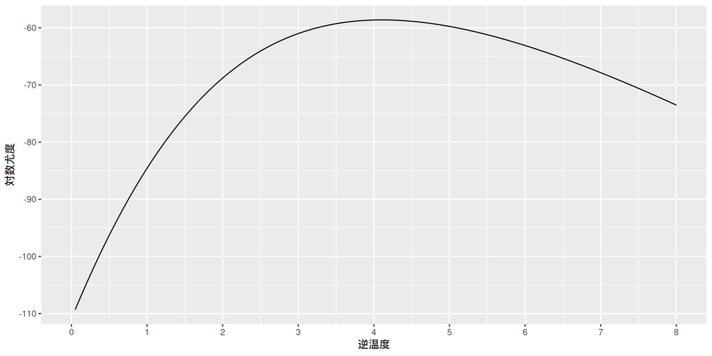

```r
 ggplot(df, aes(x = beta, y = LogLik_1))+
  geom_line()+
  scale_x_continuous(limits = c(0,8), breaks = seq(0,8,by=1))+
  xlab("逆温度")+
  ylab("対数尤度")
```

## 対数尤度の確認

- 逆温度の真値は5.0に設定したはずだけど、先ほど計算した対数尤度の最大値を求めると4.1になる。
- 試行数や課題の設定によって完全にパラメータをリカバリーできるわけではない。

```r
# 対数尤度が最大になったインデックスを確認し，kとする
k <- which.max(LogLik_1)
# そのときの逆温度を求める
betas[k]
```

```
[1] 4.1
```

## Optimを用いたパラメータ推定

- パラメータ（逆温度）の取りうる範囲で区切って対数尤度を計算したパラメータの推定値を検討する方法だと細かい推定値が出せないので、最適化関数のoptim関数を用いて推定する。
- optim関数では負の対数尤度を用いるので、その計算をする関数func_negLogLikを準備する。

```r
func_negLogLik <- function(param, data){
  -func_LogLik(param, data)
}
```

## Optimを用いたパラメータ推定

- パラメータ探索の初期値とパラメータの上限・下限を指定して、fn引数には先ほど作成した負の対数尤度を計算する関数を用いる。

```r
# 学習率と逆温度の初期値として0~1の乱数を2つ生成
initparam <- runif(2,0,1)
# 各パラメータの下限と上限
lblist <- c(0,0) #学習率も逆温度も下限は0
ublist <- c(1,20) #学習率の上限は1，逆温度の上限は20
# optim関数を使ったパラメータ推定
est <- optim(par = initparam, # パラメータの初期値
             fn = func_negLogLik,
             method="L-BFGS-B",
             lower = lblist, # パラメータの下限
             upper = ublist, # パラメータの上限
             data = data)
```

## 推定結果

- 推定したパラメータの値は大きくはズレてないけど、初期値が違うと推定がうまくいかない問題もある（後で対応）。

```r
est$par
```

```
[1] 0.2874112 3.6583344
```

- 負の対数尤度の値

```r
est$value
```

```
[1] 57.60573
```

## 初期値を変えた探索

- optimには初期値依存があるので、初期値を５回ほど変更して推定する関数func_ParamFitを準備する

```r
func_ParamFit <- function(data) {
  # 負の対数尤度の初期値は無限大にしておく
  neglogLik <- Inf
  # optim関数を使った最尤推定を5回繰り返す
  for (idx in 1:5) { #ランダムな初期値で5回推定を行う
    # 推定ごとにランダムに初期値を設定
    initparam <- runif(2,0,1) # [0,1]の一様乱数を2つ生成
    # 各パラメータの下限と上限
    lblist <- c(0,0) # 学習率も逆温度も下限は0
    ublist <- c(1,20) # 学習率の上限は1，逆温度の上限は20
    # optim 関数を使ったパラメータ推定
    est <- optim(par = initparam, #パラメータの初期値
                 fn = func_negLogLik,
                 method="L-BFGS-B",
                 lower = lblist, #パラメータの下限
                 upper = ublist, #パラメータの上限
                 control = list(trace=0), # trace=0だと出力を最小限
                 data = data)
    # 結果の出力（途中経過の確認用）
    cat("id:", data$id[1], "NegLogLik:", round(est$value,2), "Par:",round(est$par,2),"\n")
    # 負の対数尤度が最小になったときのみ記録
    if(est$value < neglogLik){
        neglogLik <- est$value # 負の対数尤度（negative log likelihood）
        paramest <- est$par # 推定されたパラメータ値
    }
  }
  # 結果のまとめ
  df <- tibble(
    id = data$id[1], # data$idは全て同じ値なので，1つ目の要素だけ取る
    neglogLik = neglogLik
  )
  for (i in 1:length(paramest)){
    df[paste0("param", i)] <- paramest[i]
  }
  # 戻り値
  df
}
```

## 初期値を変えた探索

- 初期値を変えたパラメータ推定を実行する。

```r
res <- func_ParamFit(data)
```

```
id: 1 NegLogLik: 57.61 Par: 0.29 3.66
id: 1 NegLogLik: 57.61 Par: 0.29 3.66
id: 1 NegLogLik: 57.61 Par: 0.29 3.66
id: 1 NegLogLik: 57.61 Par: 0.29 3.66
id: 1 NegLogLik: 57.61 Par: 0.29 3.66
```

## パラメータリカバリー

- 用いるモデルにおいてパラメータ推定が適切にできるかどうかを確認するにはパラメータリカバリーをする
- パラメータリカバリーでは研究者がパラメータ（真値）を指定してデータを生成し、そのデータからパラメータ推定（推定値）をして、推定値が真値を復元できているかを検討する。
- 疲労やその他の要因などは含まれない理想的な状況下での検討だが、パラメータリカバリーできないこともある。

## パラメータリカバリー用関数

- αを0から1の範囲、βを0から5の範囲でランダムに100の値を一様分布からサンプリングして、パラメータリカバリー分析を実行するfunc_ParameterRecovery関数を用意する。

```r
# パラメータリカバリー用の関数
func_ParameterRecovery <- function(n_subjects = 20){
  # ランダムパラメータの生成
  true_alphas <- runif(n_subjects, min = 0, max = 1.0)   # αを0.01-1.0の範囲でサンプリング
  true_betas <- runif(n_subjects, min = 0, max = 5.0)   # βを0.001-5.0の範囲でサンプリング

  # 結果を格納するデータフレーム
  recovery_results <- tibble(
    subject = 1:n_subjects,
    true_alpha = true_alphas,
    true_beta = true_betas,
    est_alpha = numeric(n_subjects),
    est_beta = numeric(n_subjects),
    neglogLik = numeric(n_subjects)
  )

  # 各被験者のデータ生成とパラメータ推定
  for (i in 1:n_subjects) {
    cat("Processing subject", i, "of", n_subjects, "\n")
    # 真のパラメータでデータ生成
    true_param <- c(true_alphas[i], true_betas[i])
    setting <- func_TaskSetting(0.8)
    sim_data <- func_DataGeneration(true_param, setting)
    # パラメータ推定用のデータ形式に変換
    fit_data <- tibble(
      id = rep(i, 160),
      trial = sim_data$trial,
      choice = sim_data$choice,
      reward = sim_data$reward
    )
    # パラメータ推定
    est_result <- func_ParamFit(fit_data)
    # 結果を格納
    recovery_results$est_alpha[i] <- est_result$param1
    recovery_results$est_beta[i] <- est_result$param2
    recovery_results$neglogLik[i] <- est_result$neglogLik
  }
  return(recovery_results)
}
```

## パラメータリカバリーの実施

```r
recovery_results <- func_ParameterRecovery(100)
```

```
Processing subject 1 of 100
id: 1 NegLogLik: 34.23 Par: 0.52 5.36
id: 1 NegLogLik: 34.23 Par: 0.52 5.36
id: 1 NegLogLik: 34.23 Par: 0.52 5.36
id: 1 NegLogLik: 34.23 Par: 0.52 5.36
id: 1 NegLogLik: 34.23 Par: 0.52 5.36
Processing subject 2 of 100
id: 2 NegLogLik: 104.37 Par: 0.29 1.06
id: 2 NegLogLik: 104.37 Par: 0.29 1.06
id: 2 NegLogLik: 104.37 Par: 0.29 1.06
id: 2 NegLogLik: 104.37 Par: 0.29 1.06
id: 2 NegLogLik: 104.37 Par: 0.29 1.06
Processing subject 3 of 100
id: 3 NegLogLik: 110.9 Par: 0 0
id: 3 NegLogLik: 110.64 Par: 0.32 0.21
id: 3 NegLogLik: 110.9 Par: 0 0
id: 3 NegLogLik: 110.64 Par: 0.32 0.21
id: 3 NegLogLik: 110.9 Par: 0 0
Processing subject 4 of 100
id: 4 NegLogLik: 35.32 Par: 1 20
id: 4 NegLogLik: 35.32 Par: 1 20
id: 4 NegLogLik: 35.32 Par: 1 20
id: 4 NegLogLik: 35.32 Par: 1 20
id: 4 NegLogLik: 35.32 Par: 1 20
Processing subject 5 of 100
id: 5 NegLogLik: 80.32 Par: 0.29 2.52
id: 5 NegLogLik: 80.32 Par: 0.29 2.52
id: 5 NegLogLik: 80.32 Par: 0.29 2.52
id: 5 NegLogLik: 80.32 Par: 0.29 2.52
id: 5 NegLogLik: 80.32 Par: 0.29 2.52
Processing subject 6 of 100
id: 6 NegLogLik: 104.78 Par: 0.12 1.35
id: 6 NegLogLik: 104.78 Par: 0.12 1.35
id: 6 NegLogLik: 104.78 Par: 0.12 1.35
id: 6 NegLogLik: 104.78 Par: 0.12 1.35
id: 6 NegLogLik: 104.78 Par: 0.12 1.35
Processing subject 7 of 100
id: 7 NegLogLik: 42.38 Par: 0.57 4.85
id: 7 NegLogLik: 42.38 Par: 0.57 4.85
id: 7 NegLogLik: 42.38 Par: 0.57 4.85
```

[output cut: 545 more lines]

```
id: 98 NegLogLik: 102.09 Par: 0.39 1.13
id: 98 NegLogLik: 102.09 Par: 0.39 1.13
id: 98 NegLogLik: 102.09 Par: 0.39 1.13
Processing subject 99 of 100
id: 99 NegLogLik: 107.83 Par: 0.06 1.07
id: 99 NegLogLik: 110.9 Par: 0 0
id: 99 NegLogLik: 110.9 Par: 0 0
id: 99 NegLogLik: 107.83 Par: 0.06 1.07
id: 99 NegLogLik: 110.9 Par: 0 0
Processing subject 100 of 100
id: 100 NegLogLik: 95.69 Par: 0.27 1.73
id: 100 NegLogLik: 95.69 Par: 0.27 1.73
id: 100 NegLogLik: 95.69 Par: 0.27 1.73
id: 100 NegLogLik: 95.69 Par: 0.27 1.73
id: 100 NegLogLik: 95.69 Par: 0.27 1.73
```

```r
recovery_results
```

```
# A tibble: 100 × 6
   subject true_alpha true_beta est_alpha est_beta neglogLik
     <int>      <dbl>     <dbl>     <dbl>    <dbl>     <dbl>
 1       1     0.460      4.85     0.516     5.36       34.2
 2       2     0.702      0.601    0.288     1.06      104.
 3       3     0.0869     0.442    0.323     0.208     111.
 4       4     0.993      4.40     0.996    20          35.3
 5       5     0.253      2.54     0.287     2.52       80.3
 6       6     0.0495     1.69     0.121     1.35      105.
 7       7     0.686      4.47     0.572     4.85       42.4
 8       8     0.787      0.160    0.0338    0.932     109.
 9       9     0.354      1.19     0.354     1.25       99.3
10      10     0.366      3.43     0.403     3.72       43.0
# ℹ 90 more rows
```

## パラメータリカバリー結果(α)

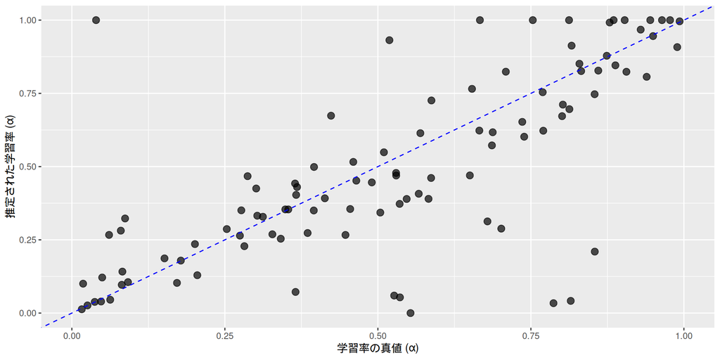

```r
ggplot(recovery_results, aes(x = true_alpha, y = est_alpha)) +
  geom_point(size = 3, alpha = 0.7) +
  geom_abline(intercept = 0, slope = 1, linetype = "dashed", color = "blue") +
  xlim(0, 1) + ylim(0, 1) +
  xlab("学習率の真値 (α)") + ylab("推定された学習率 (α)")
```

## パラメータリカバリー結果(β)

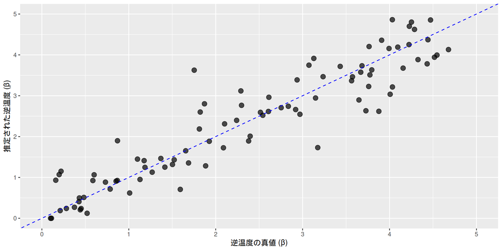

```r
ggplot(recovery_results, aes(x = true_beta, y = est_beta)) +
  geom_point(size = 3, alpha = 0.7) +
  geom_abline(intercept = 0, slope = 1, linetype = "dashed", color = "blue") +
  xlim(0, 5) + ylim(0, 5) +
  xlab("逆温度の真値 (β)") + ylab("推定された逆温度 (β)")
```

## 計算論モデリングのポイント(1)

- 計算論的モデリングの10シンプル・ルール(Wilson and Collins 2019)と[O’Reilly, Jとden Ouden, Hのチュートリアル](https://exp.socsci.ru.nl/hannekedenouden/RLtutorial/HtmlTutorial/Instructions.html)を参考にまとめる。
1. **研究計画・認知課題を適切にデザイン**：計算論モデリングはどのようなデータからも興味深い知見を提供してくれる魔法のようなものではない。計算論的モデリングにおいて適切な結論を得るには、それにあった研究計画や実験的な操作が必要。関心のある問題を最も適切に捉えられる認知課題を用いることが大切。

## 計算論モデリングのポイント(2)

2. **モデルを事前に明示的に定義**：仮説にあったモデルをデータ収集前に定義。モデルは過度に複雑にならないようシンプルなものを用いる。
3. **モデルを検討**：(1)**シミュレーション**(参加者の行動が再現されるか＆複数モデルがある場合はその挙動の違いを確認)、(2)**パラメータリカバリー**（真値を設定したシミュレーションデータから推定したパラメータが真値に近いか）、(3)**モデルリカバリー**（複数モデルがある場合、各モデル下でのシミュレーションデータに各モデルでパラメータ推定＆モデル比較し、特定のモデルの下で生成したデータがそのモデルによって最も説明できるか）

## 計算論モデリングのポイント(3)

4. **行動パターンを確認した上でモデルフィッティング**：モデルを使わない解析を行なって仮説にあう傾向があるのかを確認する。それがないならば、モデルフィッティングをしても意味はないかも。
5. **モデル比較した上で採用モデルを検討**：複数モデルがある場合は、モデル比較を行なって、採用モデルを決定する。モデル比較は相対的なものなので、モデルシミュレーションでも検討(採用モデルで推定されたパラメータを使ってシミュレーションして、参加者の行動を捉えられているか確認）

## ワーク１：自分のデータのパラメータ推定をしてみよう！

- パラメータ推定ができるように前処理を行う関数をパッケージ化しているので、そちらを使う。

```r
# install.packages("remotes")
remotes::install_github("cba-toolbox/cmot4r")
data <- PRLpreprocess::PRL_preprocess_csv("data.csv")
data
```

- この前処理ではIDをいれないので、追加する。

```r
data$id <- rep(1,80)
```

- パラメータ推定して結果を確認する。

```r
res <- func_ParamFit(data)
res
```

## ワーク２：RLモデルを改良してみよう！

- 学習率が１つ、逆温度が１つのモデル以外のモデルを試してみよう！

## 引用文献

Anticevic, Alan, and John D Murray. 2017. *Computational Psychiatry: Mathematical Modeling of Mental Illness*. Academic Press.

Huys, Quentin J M, Michael Moutoussis, and Jonathan Williams. 2011. “Are Computational Models of Any Use to Psychiatry?” *Neural Networks: The Official Journal of the International Neural Network Society* 24 (6): 544–51.

Maia, Tiago V, and Michael J Frank. 2011. “From Reinforcement Learning Models to Psychiatric and Neurological Disorders.” *Nature Neuroscience* 14 (2): 154–62.

Montague, P Read, Raymond J Dolan, Karl J Friston, and Peter Dayan. 2012. “Computational Psychiatry.” *Trends in Cognitive Sciences* 16 (1): 72–80.

Schultz, W, P Dayan, and P R Montague. 1997. “A Neural Substrate of Prediction and Reward.” *Science (New York, N.Y.)* 275 (5306): 1593–99.

Stephan, Klaas Enno, and Christoph Mathys. 2014. “Computational Approaches to Psychiatry.” *Current Opinion in Neurobiology* 25 (April): 85–92.

Wilson, Robert C, and Anne Ge Collins. 2019. “Ten Simple Rules for the Computational Modeling of Behavioral Data.” *eLife* 8 (November).

国里愛彦・片平健太郎・沖村宰・山下祐一. 2019. *計算論的精神医学：情報処理過程から読み解く精神障害*. 勁草書房.

宗田卓史, 遠山朝子, 国里愛彦, 沖村宰, 片平健太郎, and 山下祐一. 2025. *R/Pythonではじめる計算論的精神医学*. 京都: 金芳堂.